# Photoquadrats

E. Klein

20210617

last run 2021-08-28 09:06:39

# Goals

This document evaluates the performance of the CoralNet to classify rocky shores main groups from photoquadrats

The analysis comprises:

2. Compare the classification results of the visually identified quadrats with automatic classification of photoquadrats

# Data

The data is available at [CoralNet_MBON Github repository](https://github.com/gonzalobravoargentina/CoralNet_MBON). The codes for doing the analysis could be found the the Code directory of the same repo.

# Labels

```r
labelset <- read.csv("../Labelset/labelset_used.csv")

kable(labelset) %>% kable_styling("striped")
```

| Name | Short.Code | Functional.Group | ID.CoralNet | ID.CATAMI | Country |
| --- | --- | --- | --- | --- | --- |
| Bryozoan | BRY | Invertebrates | 1853 | 20000000 | US |
| Cnidaria: Colonial anemones | CNCA | Invertebrates | 4773 | 11500901 | EC |
| Cnidaria: True anemones | CNTR | Invertebrates | 4774 | 11229000 | EC,US |
| Crustacea: Barnacles | CRB | Invertebrates | 357 | 27500000 | AR,EC,CO,US |
| Molluscs: Bivalves | MOB | Invertebrates | 355 | 23199000 | AR,US |
| Molluscs: Gastropods | MOG | Invertebrates | 353 | 24000000 | CO,US |
| Sponge | SP | Invertebrates | 102 | 10000000 | AR |
| Worms: Polychaetes: Tube worms | WPOT | Invertebrates | 361 | 22000901 | AR,CO,EC |
| Substrate: Consolidated (hard) | SC | Substrate | 4114 | 82001001 |  |
| Unclear | Unc | Other | 118 | NA |  |
| Macroalgae: Articulated calcareous | MAA | Algae | 325 | 80300911 | AR,CO,US |
| Macroalgae: Erect coarse branching | MAEC | Algae | 317 | 80300903 | US |
| Macroalgae: Erect fine branching | MAEF | Algae | 313 | 80300907 | US |
| Macroalgae: Encrusting | MAEN | Algae | 321 | 80300926 | AR,EC,CO,US |
| Macroalgae: Filamentous / filiform | MAF | Algae | 309 | 80300930 | AR,EC,CO,US |
| Macroalgae: Globose / saccate | MAG | Algae | 305 | 80300914 | AR |
| Macroalgae: Laminate | MALA | Algae | 301 | 80300918 | US |
| Macroalgae: Large canopy-forming : brown | MALCB | Algae | 299 | 80300902 | AR |
| Macroalgae: Sheet-like / membraneous | MAS | Algae | 294 | 80300922 | AR,EC,US |

Proportion of the labels in the set

```r
df <- read.csv(file.path(robotDir, "annotations.csv"))
dfHuman <- df %>% filter(Comments=='random')
dfRobot <- df %>% filter(Comments=='robot')
dfSummary <- dfHuman %>% group_by(Label) %>%
  summarise(nPoints = n(), Countries = paste0(unique(country), collapse = ", ")) %>%
  mutate(Percent = round(100*nPoints/nrow(df),1)) %>%
  arrange(-nPoints)
dfSummary <- left_join(dfSummary, labelset[,c('Name', 'Short.Code')], by=c('Label'='Short.Code')) %>%
  relocate(Name, Label, nPoints, Percent, Countries)

formattable(dfSummary, list(Percent=color_bar("steelblue")))
```

| Name | Label | nPoints | Percent | Countries |
| --- | --- | --- | --- | --- |
| Substrate: Consolidated (hard) | SC | 17814 | 24.6 | ARGENTINA, COLOMBIA, ECUADOR, USA |
| Macroalgae: Erect coarse branching | MAEC | 4766 | 6.6 | USA |
| Macroalgae: Filamentous / filiform | MAF | 2931 | 4.0 | ARGENTINA, COLOMBIA, ECUADOR, USA |
| Macroalgae: Encrusting | MAEN | 2891 | 4.0 | ARGENTINA, COLOMBIA, ECUADOR, USA |
| Molluscs: Bivalves | MOB | 2753 | 3.8 | ARGENTINA, USA |
| Crustacea: Barnacles | CRB | 2196 | 3.0 | ARGENTINA, COLOMBIA, ECUADOR, USA |
| Macroalgae: Sheet-like / membraneous | MAS | 1418 | 2.0 | ARGENTINA, COLOMBIA, USA |
| Macroalgae: Articulated calcareous | MAA | 612 | 0.8 | ARGENTINA, COLOMBIA |
| Worms: Polychaetes: Tube worms | WPOT | 283 | 0.4 | ARGENTINA, COLOMBIA, ECUADOR |
| Unclear | Unc | 179 | 0.2 | ARGENTINA, COLOMBIA, ECUADOR, USA |
| Molluscs: Gastropods | MOG | 145 | 0.2 | COLOMBIA, USA |
| Macroalgae: Large canopy-forming : brown | MALCB | 73 | 0.1 | ARGENTINA |
| Bryozoan | BRY | 66 | 0.1 | USA |
| Macroalgae: Laminate | MALA | 55 | 0.1 | USA |
| Macroalgae: Erect fine branching | MAEF | 9 | 0.0 | USA |
| Cnidaria: True anemones | CNTR | 4 | 0.0 | ECUADOR, USA |
| Cnidaria: Colonial anemones | CNCA | 3 | 0.0 | ECUADOR |
| Macroalgae: Globose / saccate | MAG | 2 | 0.0 | ARGENTINA |

As functional groups the labels and its representation in the data set:

```r
dfFuncGroup <- left_join(df, labelset[,c('Functional.Group', 'Short.Code')], by=c('Label'='Short.Code') )
dfSummary <- dfFuncGroup %>% group_by(Functional.Group) %>%
  summarise(nPoints = n(), Countries = paste0(unique(country), collapse = ", ")) %>%
  mutate(Percent = round(100*nPoints/nrow(df),1)) %>%
  relocate(Functional.Group, nPoints, Percent, Countries) %>%
  arrange(-nPoints)

formattable(dfSummary, list(Percent=color_bar("steelblue")), caption="Functional groups label set")
```

Functional groups label set

| Functional.Group | nPoints | Percent | Countries |
| --- | --- | --- | --- |
| Substrate | 36673 | 50.7 | ARGENTINA, COLOMBIA, ECUADOR, USA |
| Algae | 24736 | 34.2 | ARGENTINA, COLOMBIA, ECUADOR, USA |
| Invertebrates | 10719 | 14.8 | ARGENTINA, COLOMBIA, ECUADOR, USA |
| Other | 272 | 0.4 | ARGENTINA, COLOMBIA, ECUADOR, USA |

# Full Community

## Photoquadrats vs Robot

This compares the classification of the 100 point grid labels from the photo quadrats to the output of the robot. We will use the same Bray-Curtis approach as we’re interested in the composition of the community. If the robot is good enough, the BC distance must remain close to zero in the majority of the quadrats.

We will use the labels that contribute in total up to 95% of all the records. The reason behind this is that with few rare labels used in the training of the robot, the classification accuracy of these labels are expected to be low, hence producing an artificially higher Bray-Curtis distance.

```r
## get fotoquadrat human community data
CM_HumanRobot <- read.csv(file.path(cleandataDir, "DF_HumanRobot.csv"))
humanLabels <- CM_HumanRobot %>% filter(source=="human") %>%
  group_by(Label) %>%
  summarise(n=sum(Cover)) %>%
  arrange(-n) %>%
  mutate(acum=cumsum(n), acumP = acum/sum(n))
humanLabels95 <- humanLabels$Label[humanLabels$acumP<=0.96]

## make community matrix from robot
robotLabels <- CM_HumanRobot %>% filter(source=="robot") %>%
  group_by(Label) %>%
  summarise(n=sum(Cover)) %>%
  arrange(-n) %>%
  mutate(acum=cumsum(n), acumP = acum/sum(n))
robotLabels95 <- robotLabels$Label[robotLabels$acumP<=0.96]

## intersect the set of both labels and use only 95% labels
labels95 <- intersect(humanLabels95, robotLabels95)
CM_HumanRobot95 <- CM_HumanRobot %>% filter(Label %in% labels95)

## make it wide
CM_HumanRobot95_wide <- CM_HumanRobot95 %>% pivot_wider(id_cols = Name:strata, names_from = 'Label', values_from = 'Cover')
CM_HumanRobot95_wide[is.na(CM_HumanRobot95_wide)] <- 0
CM_Human95 <- CM_HumanRobot95_wide %>% filter(source=="human")
CM_Robot95 <- CM_HumanRobot95_wide %>% filter(source=="robot")
```

Generate the BC table. For each photo (Name) build a two-row community matrix (row1: Human, row2: Robot), and calculate the BC distance.

```r
## calculate BC index
BC_RH <- data.frame(Name=character(), BC=numeric())
nLabels <- ncol(CM_Human95)
for (i in 1:nrow(CM_Human95)){
  robotIndex <- which(CM_Robot95$Name==CM_Human95$Name[i])
  if (length(robotIndex) > 0 ){
    CM_one <- bind_rows(CM_Human95[i,6:nLabels], CM_Robot95[robotIndex,6:nLabels])
    CM_one[is.na(CM_one)] <- 0
    BC_RH <- bind_rows(BC_RH,
                    data.frame(Name = CM_Human95$Name[i],
                               BC = as.numeric(vegdist(CM_one, na.rm = T))))
  }else {
    print(paste0("NOT FOUND in Robot: ", CM_Visual$Name[i]))
  }
}

## fix the mess US did with the Human and Robot Name (that sounds deep, very deep!)
BC_RH$Country <- str_sub(BC_RH$Name,1,2)
BC_RH$Site <- ifelse(BC_RH$Country=='US', str_sub(BC_RH$Name,3,6),str_split(BC_RH$Name, "_", simplify = T)[,3] )
BC_RH$Strata <- ifelse(BC_RH$Country=='US', str_split(BC_RH$Name, "_", simplify = T)[,3],
                            str_split(BC_RH$Name, "_", simplify = T)[,4])
BC_RH$Strata <- recode_factor(BC_RH$Strata, low="MT", high="HT")


## recode locations
BC_RH$Site <- recode_factor(BC_RH$Site, PC="Punta Cuevas", PE="Punta Este", PL="Punta Lobos",
                            LM="La Mancora", LV="La Ventana", PV="Playa Verde",
                            CD="Charles Darwin Station", RA="Ratonera", TO="Tortuga Bay",
                            MAMH="MAMH", MAPH="MAPH", MECH="MECH", MEGS="MEGS")
BC_RH$Strata <- recode_factor(BC_RH$Strata, LT="LOWTIDE", MT="MIDTIDE", HT="HIGHTIDE")
```

Summarise the BS distances by groups

```r
BCsummary <- BC_RH %>% group_by(Strata) %>%
  summarise(BCmean = mean(BC),
            BCsd = sd(BC),
            BCq25 = quantile(BC, 0.25),
            BCq50 = quantile(BC, 0.50),
            BCq74 = quantile(BC, 0.75),
            BCmin = min(BC),
            BCmax = max(BC))

kable(BCsummary, digits=3, caption = "All labels: HUMAN vs ROBOT") %>% kable_styling("striped")
```

All labels: HUMAN vs ROBOT

| Strata | BCmean | BCsd | BCq25 | BCq50 | BCq74 | BCmin | BCmax |
| --- | --- | --- | --- | --- | --- | --- | --- |
| LOWTIDE | 0.124 | 0.113 | 0.048 | 0.101 | 0.168 | 0 | 0.704 |
| MIDTIDE | 0.070 | 0.088 | 0.020 | 0.046 | 0.085 | 0 | 0.600 |
| HIGHTIDE | 0.046 | 0.066 | 0.000 | 0.021 | 0.060 | 0 | 0.327 |

```r
BCsummaryGlobal <- BC_RH %>%
  summarise(BCmean = mean(BC),
            BCsd = sd(BC),
            BCq25 = quantile(BC, 0.25),
            BCq50 = quantile(BC, 0.50),
            BCq74 = quantile(BC, 0.75),
            BCmin = min(BC),
            BCmax = max(BC))

kable(BCsummaryGlobal, digits=3, caption = "All Labels: HUMAN vs ROBOT global BC stats") %>% kable_styling("striped")
```

All Labels: HUMAN vs ROBOT global BC stats

| BCmean | BCsd | BCq25 | BCq50 | BCq74 | BCmin | BCmax |
| --- | --- | --- | --- | --- | --- | --- |
| 0.074 | 0.093 | 0.016 | 0.045 | 0.1 | 0 | 0.704 |

Plot the BC distances by strata and country:

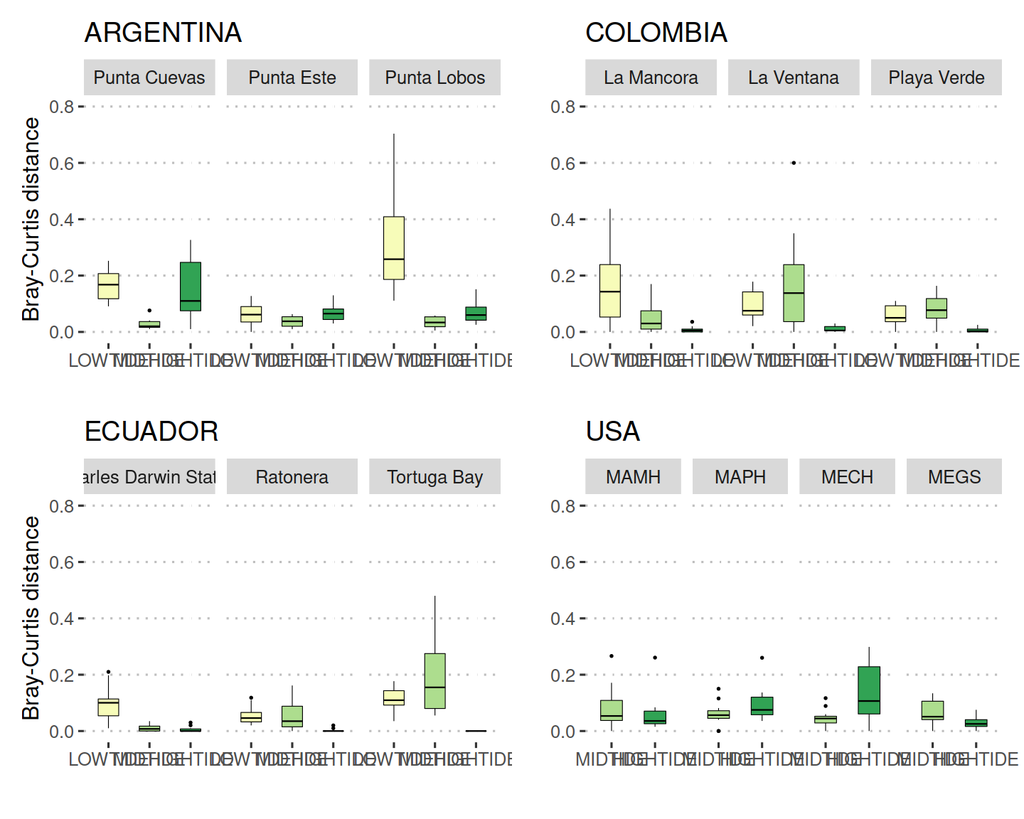

```r
strataColor = c(LOWTIDE="#f7fcb9", MIDTIDE="#addd8e", HIGHTIDE="#31a354")

pp_ARG <- ggplot(BC_RH %>% filter(Country=="AR"), aes(Strata, BC))
pp_ARG <- pp_ARG + geom_boxplot(width=0.5, aes(fill=Strata), colour="black", outlier.size = 0.3, lwd=0.2) +
  ylim(0,0.8) +
  scale_color_manual(values = strataColor, aesthetics = 'fill') +
  labs(title="ARGENTINA", x="", y="Bray-Curtis distance") +
  facet_grid(~Site) +
  theme_pubclean() +
  theme(legend.position = 'none')

pp_COL <- ggplot(BC_RH %>% filter(Country=="CO"), aes(Strata, BC))
pp_COL <- pp_COL + geom_boxplot(width=0.5, aes(fill=Strata), colour="black", outlier.size = 0.3, lwd=0.2) +
  ylim(0,0.8) +
  scale_color_manual(values = strataColor, aesthetics = 'fill') +
  labs(title="COLOMBIA", x="", y=" ") +
  facet_grid(~Site) +
  theme_pubclean() +
  theme(legend.position = 'none')

pp_ECU <- ggplot(BC_RH %>% filter(Country=="EC"), aes(Strata, BC))
pp_ECU <- pp_ECU + geom_boxplot(width=0.5, aes(fill=Strata), colour="black", outlier.size = 0.3, lwd=0.2) +
  ylim(0,0.8) +
  scale_color_manual(values = strataColor, aesthetics = 'fill') +
  labs(title="ECUADOR", x="", y="Bray-Curtis distance") +
  facet_grid(~Site) +
  theme_pubclean() +
  theme(legend.position = 'none')

pp_USA <- ggplot(BC_RH %>% filter(Country=="US"), aes(Strata, BC))
pp_USA <- pp_USA + geom_boxplot(width=0.5, aes(fill=Strata), colour="black", outlier.size = 0.3, lwd=0.2) +
  ylim(0,0.8) +
  scale_color_manual(values = strataColor, aesthetics = 'fill') +
  labs(title="USA", x="", y=" ") +
  facet_grid(~Site) +
  theme_pubclean() +
  theme(legend.position = 'none')

(pp_ARG + pp_COL) / (pp_ECU + pp_USA)
```

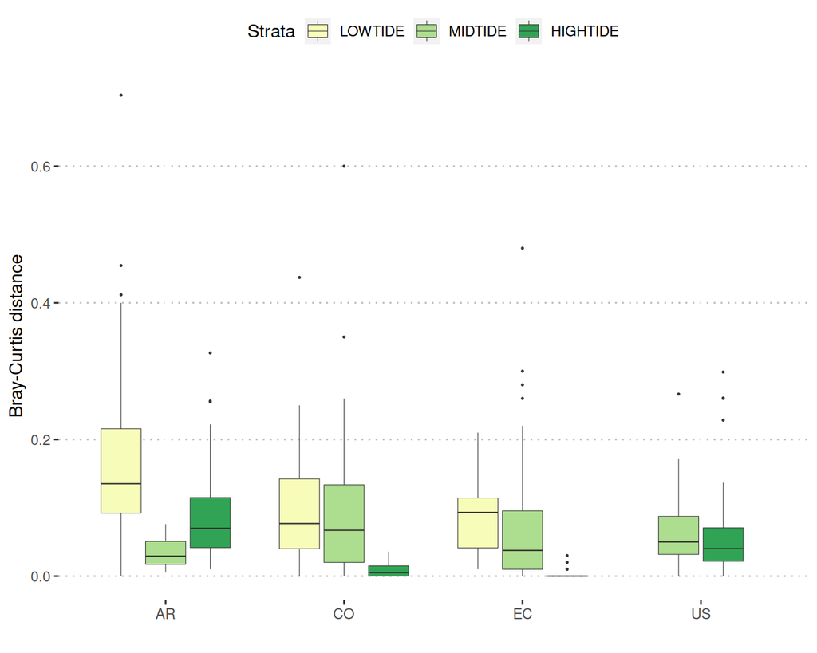

```r
pp <- ggplot(BC_RH, aes(Country, BC, fill=Strata))
pp + geom_boxplot(position=position_dodge2(preserve = "single"), aes(fill=Strata), outlier.size = 0.3, lwd=0.2) +
  labs(x="", y="Bray-Curtis distance") +
  scale_color_manual(values = strataColor, aesthetics = 'fill') +
  theme_pubclean()
```

Let’s try another version

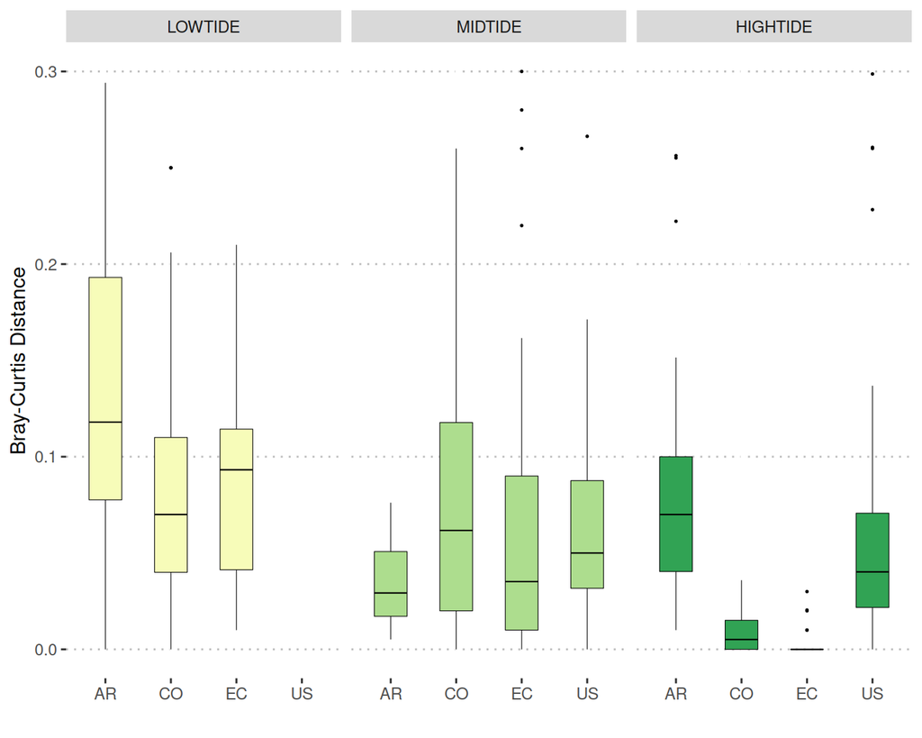

```r
pp <- ggplot(BC_RH, aes(Country, BC, fill=Strata))
pp + geom_boxplot(width=0.5, aes(fill=Strata), colour="black", position=position_dodge2(preserve="single") , outlier.size = 0.3, lwd=0.2) +
  scale_color_manual(values = strataColor, aesthetics = 'fill') +
  ylim(0, 0.3) +
  labs(x="", y="Bray-Curtis Distance") +
  facet_grid(~Strata) +
  theme_pubclean() +
  theme(legend.position = 'none')
```

Apply a GMM nested model

```r
BC_RH <- BC_RH %>%
  group_by(Country, Site, Strata) %>%
  mutate(Quadrat=1:n())

model = glmer(BC ~ Country + Strata + Country*Strata + (1|Site/Quadrat), data=BC_RH, family=binomial)
summary(model)
```

```
Generalized linear mixed model fit by maximum likelihood (Laplace Approximation) ['glmerMod']
 Family: binomial  ( logit )
Formula: BC ~ Country + Strata + Country * Strata + (1 | Site/Quadrat)
   Data: BC_RH

     AIC      BIC   logLik deviance df.resid
    43.5     94.1     -8.8     17.5      349

Scaled residuals:
     Min       1Q   Median       3Q      Max
       0        1  1728955  4048555 32212255

Random effects:
 Groups       Name        Variance  Std.Dev.
 Quadrat:Site (Intercept) 1.828e-17 4.275e-09
 Site         (Intercept) 2.317e-19 4.813e-10
Number of obs: 362, groups:  Quadrat:Site, 144; Site, 13

Fixed effects:
                           Estimate Std. Error z value Pr(>|z|)
(Intercept)              -3.367e+00  1.017e+00  -3.311 0.000931 ***
CountryCO                -4.005e+02  1.218e+07   0.000 0.999974
CountryEC                -1.590e+02  1.225e+07   0.000 0.999990
CountryUS                 8.726e+01  1.416e+07   0.000 0.999995
StrataMIDTIDE            -1.583e+02  1.226e+07   0.000 0.999990
StrataHIGHTIDE           -1.193e+02  1.225e+07   0.000 0.999992
CountryCO:StrataMIDTIDE   5.588e+02  1.726e+07   0.000 0.999974
CountryEC:StrataMIDTIDE  -2.481e+02  2.122e+07   0.000 0.999991
CountryUS:StrataMIDTIDE  -3.127e+02  2.118e+07   0.000 0.999988
CountryCO:StrataHIGHTIDE -1.143e+02  2.118e+07   0.000 0.999996
CountryEC:StrataHIGHTIDE -1.055e+03  2.122e+07   0.000 0.999960
---
Signif. codes:  0 '***' 0.001 '**' 0.01 '*' 0.05 '.' 0.1 ' ' 1

Correlation of Fixed Effects:
            (Intr) CntrCO CntrEC CntrUS SMIDTI SHIGHT CCO:SM CEC:SM CUS:SM CCO:SH
CountryCO    0.000
CountryEC    0.000  0.000
CountryUS    0.000  0.000  0.000
StrtMIDTIDE  0.000 -0.003  0.000  0.000
StrHIGHTIDE  0.000  0.000  0.000 -0.865  0.000
CCO:SMIDTID  0.000 -0.704  0.000  0.000 -0.708  0.000
CEC:SMIDTID  0.000  0.002 -0.577  0.000 -0.578  0.000  0.409
CUS:SMIDTID  0.000  0.002  0.000 -0.669 -0.579  0.578  0.410  0.334
CCO:SHIGHTI  0.000 -0.575  0.000  0.500  0.002 -0.578  0.405 -0.001 -0.336
CEC:SHIGHTI  0.000  0.000 -0.577  0.500  0.000 -0.577  0.000  0.333 -0.334  0.334
fit warnings:
fixed-effect model matrix is rank deficient so dropping 1 column / coefficient
convergence code: 0
boundary (singular) fit: see ?isSingular
```

```r
#model_glm <- glm(BC ~ Country*Strata, data=BC_RH, family=binomial)
#summary(model_glm)

testCountry = glht(model, linfct = mcp(Country = "Tukey"))
summary(testCountry)
```

```
     Simultaneous Tests for General Linear Hypotheses

Multiple Comparisons of Means: Tukey Contrasts


Fit: glmer(formula = BC ~ Country + Strata + Country * Strata + (1 |
    Site/Quadrat), data = BC_RH, family = binomial)

Linear Hypotheses:
               Estimate Std. Error z value Pr(>|z|)
CO - AR == 0 -4.005e+02  1.218e+07       0        1
EC - AR == 0 -1.590e+02  1.225e+07       0        1
US - AR == 0  8.726e+01  1.416e+07       0        1
EC - CO == 0  2.415e+02  1.728e+07       0        1
US - CO == 0  4.878e+02  1.868e+07       0        1
US - EC == 0  2.463e+02  1.873e+07       0        1
(Adjusted p values reported -- single-step method)
```

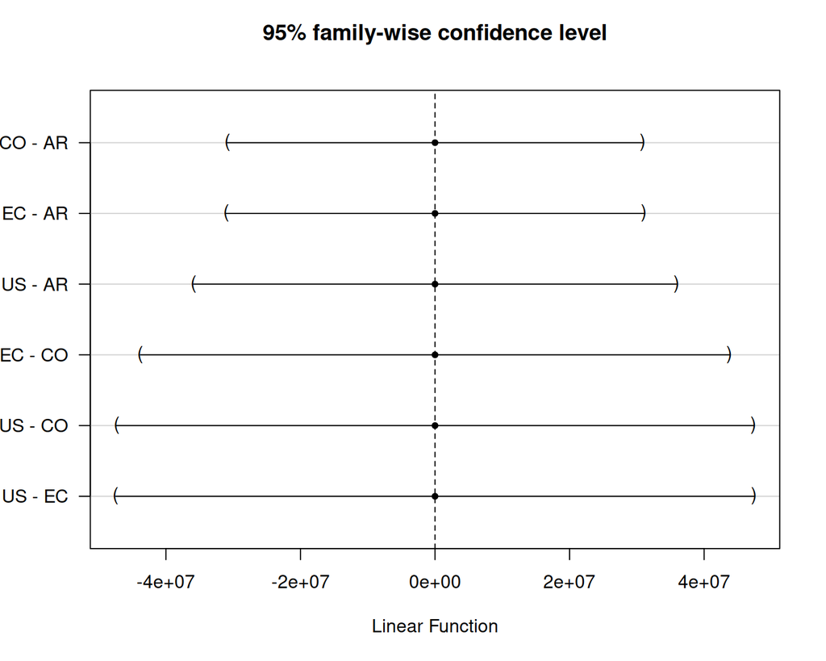

```r
plot(confint(testCountry))
```

There is no sig differences between the estimates of community composition between strata or countries.

```r
BCmean <- round(mean(BC_RH$BC),3)
BCn <- nrow(BC_RH)
BCsd <- sd(BC_RH$BC)
BCmargin <- qt(0.975,df=BCn-1)*BCsd/sqrt(BCn)
BCupper <- round(BCmean + BCmargin, 3)
BClower <- round(BCmean - BCmargin, 3)
```

As demonstrated, the classifier is insensitive to the variability produced by Country and Strata, being equally efficient no matter the source of the quadrat. **In general, the difference between the classifier and the visual estimate of the community cover of a mean quadrat is 0.074 with a 95% confidence interval of [0.064 - 0.084]**

## Similarity with visual

The idea here is to test if there is differences between the quadrat surveyed in the field and analysed visually with the result of the classifier over the same quadrats.

As we don’t label every point in the quadrat in the field, it is not possible to make a point-to-point comparison. However, if we estimate the cover of each of the categories in each of the quadrats and do the same with the result of the classifier, it will be possible to calculate a distance metric that represent how different are the estimates. AS we are dealing with counts (number of points in each category), a Bray-Curtis distance is appropriate. Here the hypothesis is that if both methods produce the same result, the BC distance must be zero.

For each quadrat it is possible to make a community matrix: 2 rows, visual and machine estimates, and n columns, being n the number of labels). Then we can calculate the BC distance comparing the two methods.

Then we can compare the BC distances (as proportions) using a generalized nested mixed models.

Method:

1. bind visual cover estimates from all sites, except USA, as the USA photoquadrats does not coincide with the quadrats used for visual estimates

```r
## it may be repeated but letś do it again in case we want to do a separate analysis
## get Visual data
CM_Visual <- read_csv(file.path(cleandataDir, "CM_visual.csv"), col_types = cols())
CM_Robot <- read_csv(file.path(cleandataDir, "CM_robot.csv"), col_types = cols())

##match the robot labels to visual labels
labelsVisual <- colnames(CM_Visual)[6:ncol(CM_Visual)]
CM_Robot <- CM_Robot %>% dplyr::select(Name:strata,  contains(labelsVisual))

## replace NA by zero
CM_Visual[is.na(CM_Visual)] <- 0
CM_Robot[is.na(CM_Robot)] <- 0
```

#### Full Label Set

We will use the only the labels produced by the classifier as the label set. We will drop not used labels from the visual and recalculate the cover.

```r
## calculate BC index
nLabels <- ncol(CM_Visual)

BC_VR <- data.frame(Country=character(), Site=character(), Strata=character(), BC=numeric())
for (i in 1:nrow(CM_Visual)){
  robotIndex <- which(CM_Robot$Name==CM_Visual$Name[i])
  if (length(robotIndex) > 0 ){
    CM_one <- bind_rows(CM_Visual[i,6:nLabels], CM_Robot[robotIndex,6:nLabels])
    CM_one[is.na(CM_one)] <- 0
    BC_VR <- bind_rows(BC_VR,
                    data.frame(Country = CM_Visual$country[i],
                               Site = CM_Visual$site[i],
                               Strata = CM_Visual$strata[i],
                               BC = as.numeric(vegdist(CM_one, na.rm = T))))
  }else {
    print(paste0("NOT FOUND in Robot: ", CM_Visual$Name[i]))
  }
}
BC_VR$Site <- recode_factor(BC_VR$Site, PC="Punta Cuevas", PE="Punta Este", PL="Punta Lobos",
                            LM="La Mancora", LV="La Ventana", PV="Playa Verde",
                            CD="Charles Darwin Station", RA="Ratonera", TO="Tortuga Bay",
                            MAMH="MAMH", MAPH="MAPH", MECH="MECH", MEGS="MEGS")
BC_VR$Strata <- factor(BC_VR$Strata, levels = c("LT", "MT", "HT"), labels = c("LOWTIDE", "MIDTIDE", "HIGHTIDE"))
BC_VR$Country <- factor(BC_VR$Country, levels = c("AR", "CO", "EC"), labels = c("ARGENTINA", "COLOMBIA", "ECUADOR"))
```

Summarise the BS distances by groups

```r
BCsummary <- BC_VR %>% group_by(Strata) %>%
  summarise(BCmean = mean(BC),
            BCsd = sd(BC),
            BCq25 = quantile(BC, 0.25),
            BCq50 = quantile(BC, 0.50),
            BCq74 = quantile(BC, 0.75),
            BCmin = min(BC),
            BCmax = max(BC))

kable(BCsummary, digits=3, caption = "All labels: VISUAL vs. ROBOT") %>% kable_styling("striped")
```

All labels: VISUAL vs. ROBOT

| Strata | BCmean | BCsd | BCq25 | BCq50 | BCq74 | BCmin | BCmax |
| --- | --- | --- | --- | --- | --- | --- | --- |
| LOWTIDE | 0.213 | 0.152 | 0.094 | 0.178 | 0.335 | 0 | 0.65 |
| MIDTIDE | 0.111 | 0.125 | 0.030 | 0.060 | 0.168 | 0 | 0.62 |
| HIGHTIDE | 0.062 | 0.104 | 0.000 | 0.020 | 0.078 | 0 | 0.48 |

```r
BCsummaryGlobal <- BC_VR %>%
  summarise(BCmean = mean(BC),
            BCsd = sd(BC),
            BCq25 = quantile(BC, 0.25),
            BCq50 = quantile(BC, 0.50),
            BCq74 = quantile(BC, 0.75),
            BCmin = min(BC),
            BCmax = max(BC))

kable(BCsummaryGlobal, digits=3, caption = "All Labels: VISUAL vs ROBOT global BC stats") %>% kable_styling("striped")
```

All Labels: VISUAL vs ROBOT global BC stats

| BCmean | BCsd | BCq25 | BCq50 | BCq74 | BCmin | BCmax |
| --- | --- | --- | --- | --- | --- | --- |
| 0.129 | 0.143 | 0.02 | 0.08 | 0.184 | 0 | 0.65 |

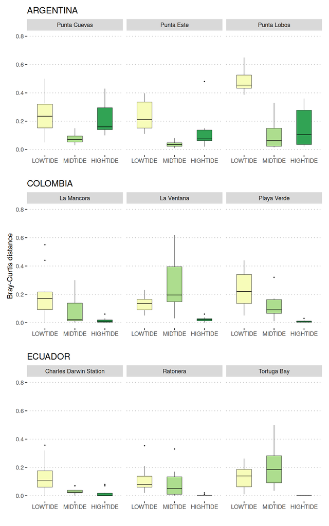

```r
pp_ARG <- ggplot(BC_VR %>% filter(Country=="ARGENTINA"), aes(Strata, BC))
pp_ARG <- pp_ARG + geom_boxplot(width=0.5, aes(fill=Strata), colour="black", outlier.size = 0.3, lwd=0.2) +
  ylim(0,0.8) +
  scale_color_manual(values = strataColor, aesthetics = 'fill') +
  labs(title="ARGENTINA", x="", y=" ") +
  facet_grid(~Site) +
  theme_pubclean() +
  theme(legend.position = 'none')

pp_COL <- ggplot(BC_VR %>% filter(Country=="COLOMBIA"), aes(Strata, BC))
pp_COL <- pp_COL + geom_boxplot(width=0.5, aes(fill=Strata), colour="black", outlier.size = 0.3, lwd=0.2) +
  ylim(0,0.8) +
  scale_color_manual(values = strataColor, aesthetics = 'fill') +
  labs(title="COLOMBIA", x="", y="Bray-Curtis distance") +
  facet_grid(~Site) +
  theme_pubclean() +
  theme(legend.position = 'none')

pp_ECU <- ggplot(BC_VR %>% filter(Country=="ECUADOR"), aes(Strata, BC))
pp_ECU <- pp_ECU + geom_boxplot(width=0.5, aes(fill=Strata), colour="black", outlier.size = 0.3, lwd=0.2) +
  ylim(0,0.8) +
  scale_color_manual(values = strataColor, aesthetics = 'fill') +
  labs(title="ECUADOR", x="", y=" ") +
  facet_grid(~Site) +
  theme_pubclean() +
  theme(legend.position = 'none')

pp_ARG / pp_COL / pp_ECU
```

#### Reduced Label Set

Let’s try to reduce the number of labels to the most representative ones. It makes sense as the infrequent labels have poorly accuracy in the classifier as the number of training points is very low.

Try with the labels that are present in 99.5% of the points in the Visual file:

This is the number of points and accumulated % per label:

```r
DF_VisualRobot <- read_csv(file.path(cleandataDir, "DF_VisualRobot.csv"), col_types = cols())

labelTable <- DF_VisualRobot %>% group_by(Label) %>%
  summarise(VISUAL = sum(Cover[source=='visual']), ROBOT = sum(Cover[source=='robot'])) %>%
  arrange(-VISUAL) %>%
  mutate(VISUALcum = round(100*cumsum(VISUAL)/sum(VISUAL),2),
         ROBOTcum = round(100*cumsum(ROBOT)/sum(ROBOT),2))

kable(labelTable) %>% kable_styling("striped")
```

| Label | VISUAL | ROBOT | VISUALcum | ROBOTcum |
| --- | --- | --- | --- | --- |
| SC | 16661 | 18859 | 79.27 | 63.45 |
| MOB | 2659 | 2652 | 91.92 | 72.37 |
| MAA | 1131 | 509 | 97.30 | 74.08 |
| WPOT | 297 | 239 | 98.72 | 74.89 |
| CRB | 177 | 2277 | 99.56 | 82.55 |
| MOG | 54 | 101 | 99.81 | 82.89 |
| CNTR | 30 | 0 | 99.96 | 82.89 |
| CNCA | 9 | 0 | 100.00 | 82.89 |
| BRY | 0 | 0 | 100.00 | 82.89 |
| MAEC | 0 | 4993 | 100.00 | 99.69 |
| MAEF | 0 | 0 | 100.00 | 99.69 |
| SP | 0 | 0 | 100.00 | 99.69 |
| Unc | 0 | 93 | 100.00 | 100.00 |

```r
labels995 <- labelTable$Label[labelTable$VISUALcum <= 99.6]
```

The labels that accumulate up to 99.6% of the points are:

```r
cat(labels995)
```

```
SC MOB MAA WPOT CRB
```

```r
## Filter robot labels using selected visual labels
CM_Robot995 <- CM_Robot %>% dplyr::select(Name:strata, contains(labels995))
CM_Visual995 <- CM_Visual %>% dplyr::select(Name:strata, contains(labels995))

## calculate BC index
BC_VR995 <- data.frame(Country=character(), Site=character(), Strata=character(), BC=numeric())
for (i in 1:nrow(CM_Visual995)){
  robotIndex <- which(CM_Robot995$Name==CM_Visual995$Name[i])
  if (length(robotIndex) > 0 ){
    CM_one <- bind_rows(CM_Visual995[i,6:ncol(CM_Visual995)], CM_Robot995[robotIndex,6:ncol(CM_Robot995)])
    CM_one[is.na(CM_one)] <- 0
    BC_VR995 <- bind_rows(BC_VR995,
                    data.frame(Country = CM_Visual995$country[i],
                               Site = CM_Visual995$site[i],
                               Strata = CM_Visual995$strata[i],
                               BC = as.numeric(vegdist(CM_one, na.rm = T))))
  }else {
    print(paste0("NOT FOUND in Robot: ", CM_Visual$Name[i]))
  }
}
BC_VR995$Site <- recode_factor(BC_VR995$Site, PC="Punta Cuevas", PE="Punta Este", PL="Punta Lobos",
                            LM="La Mancora", LV="La Ventana", PV="Playa Verde",
                            CD="Charles Darwin Station", RA="Ratonera", TO="Tortuga Bay",
                            MAMH="MAMH", MAPH="MAPH", MECH="MECH", MEGS="MEGS")
BC_VR995$Strata <- factor(BC_VR995$Strata, levels = c("LT", "MT", "HT"), labels = c("LOWTIDE", "MIDTIDE", "HIGHTIDE"))
BC_VR995$Country <- factor(BC_VR995$Country, levels = c("AR", "CO", "EC"), labels = c("ARGENTINA", "COLOMBIA", "ECUADOR"))
```

Summarise the BS distances by groups

```r
BCsummary <- BC_VR995 %>% group_by(Strata) %>%
  summarise(BCmean = mean(BC),
            BCsd = sd(BC),
            BCq25 = quantile(BC, 0.25),
            BCq50 = quantile(BC, 0.50),
            BCq74 = quantile(BC, 0.75),
            BCmin = min(BC),
            BCmax = max(BC))

kable(BCsummary, digits=3, caption = "All labels: VISUAL vs. ROBOT") %>% kable_styling("striped")
```

All labels: VISUAL vs. ROBOT

| Strata | BCmean | BCsd | BCq25 | BCq50 | BCq74 | BCmin | BCmax |
| --- | --- | --- | --- | --- | --- | --- | --- |
| LOWTIDE | 0.236 | 0.215 | 0.056 | 0.179 | 0.356 | 0 | 1.000 |
| MIDTIDE | 0.098 | 0.132 | 0.015 | 0.052 | 0.119 | 0 | 0.806 |
| HIGHTIDE | 0.056 | 0.106 | 0.000 | 0.008 | 0.053 | 0 | 0.442 |

```r
## global stats
BCsummaryGlobal <- BC_VR995 %>%
  summarise(BCmean = mean(BC),
            BCsd = sd(BC),
            BCq25 = quantile(BC, 0.25),
            BCq50 = quantile(BC, 0.50),
            BCq74 = quantile(BC, 0.75),
            BCmin = min(BC),
            BCmax = max(BC))

kable(BCsummaryGlobal, digits=3, caption = "95% Labels: VISUAL vs ROBOT global BC stats") %>% kable_styling("striped")
```

95% Labels: VISUAL vs ROBOT global BC stats

| BCmean | BCsd | BCq25 | BCq50 | BCq74 | BCmin | BCmax |
| --- | --- | --- | --- | --- | --- | --- |
| 0.13 | 0.176 | 0.01 | 0.053 | 0.193 | 0 | 1 |

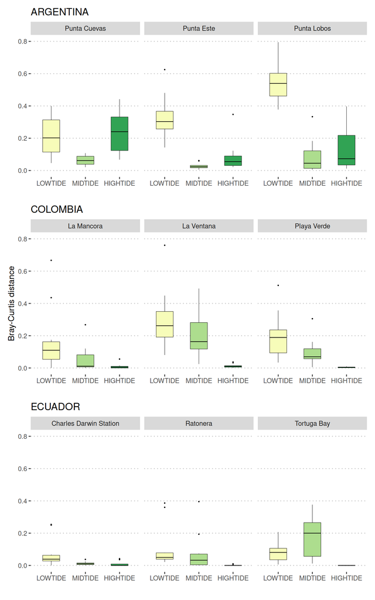

```r
pp_ARG <- ggplot(BC_VR995 %>% filter(Country=="ARGENTINA"), aes(Strata, BC))
pp_ARG <- pp_ARG + geom_boxplot(width=0.5, aes(fill=Strata), colour="black", outlier.size = 0.3, lwd=0.2) +
  ylim(0,0.8) +
  scale_color_manual(values = strataColor, aesthetics = 'fill') +
  labs(title="ARGENTINA", x="", y=" ") +
  facet_grid(~Site) +
  theme_pubclean() +
  theme(legend.position = 'none')

pp_COL <- ggplot(BC_VR995 %>% filter(Country=="COLOMBIA"), aes(Strata, BC))
pp_COL <- pp_COL + geom_boxplot(width=0.5, aes(fill=Strata), colour="black", outlier.size = 0.3, lwd=0.2) +
  ylim(0,0.8) +
  scale_color_manual(values = strataColor, aesthetics = 'fill') +
  labs(title="COLOMBIA", x="", y="Bray-Curtis distance") +
  facet_grid(~Site) +
  theme_pubclean() +
  theme(legend.position = 'none')

pp_ECU <- ggplot(BC_VR995 %>% filter(Country=="ECUADOR"), aes(Strata, BC))
pp_ECU <- pp_ECU + geom_boxplot(width=0.5, aes(fill=Strata), colour="black", outlier.size = 0.3, lwd=0.2) +
  ylim(0,0.8) +
  scale_color_manual(values = strataColor, aesthetics = 'fill') +
  labs(title="ECUADOR", x="", y=" ") +
  facet_grid(~Site) +
  theme_pubclean() +
  theme(legend.position = 'none')

pp_ARG / pp_COL / pp_ECU
```

Let’s try another version

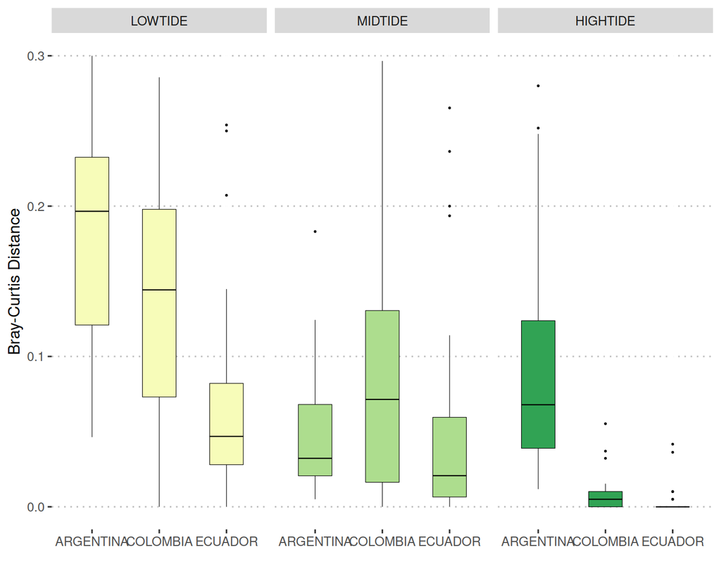

```r
pp <- ggplot(BC_VR995, aes(Country, BC, fill=Strata))
pp + geom_boxplot(width=0.5, aes(fill=Strata), colour="black", position=position_dodge2(preserve="single") , outlier.size = 0.3, lwd=0.2) +
  scale_color_manual(values = strataColor, aesthetics = 'fill') +
  ylim(0, 0.3) +
  labs(x="", y="Bray-Curtis Distance") +
  facet_grid(~Strata) +
  theme_pubclean() +
  theme(legend.position = 'none')
```

Description of the BC values

```r
BCsummary <- BC_VR995 %>% group_by(Country, Site, Strata) %>%
  summarize(n = n(), BCmean = mean(BC), BCsd = sd(BC), BCmin = min(BC), BCmax = max(BC),
            BCq25 = quantile(BC, 0.25), BCmedian = median(BC), BCq75 = quantile(BC, 0.75))

kable(BCsummary, digits=2) %>% kable_styling("striped", full_width = FALSE)
```

| Country | Site | Strata | n | BCmean | BCsd | BCmin | BCmax | BCq25 | BCmedian | BCq75 |
| --- | --- | --- | --- | --- | --- | --- | --- | --- | --- | --- |
| ARGENTINA | Punta Cuevas | LOWTIDE | 10 | 0.21 | 0.12 | 0.05 | 0.40 | 0.11 | 0.20 | 0.31 |
| ARGENTINA | Punta Cuevas | MIDTIDE | 10 | 0.06 | 0.03 | 0.02 | 0.11 | 0.04 | 0.06 | 0.09 |
| ARGENTINA | Punta Cuevas | HIGHTIDE | 10 | 0.24 | 0.14 | 0.07 | 0.44 | 0.12 | 0.24 | 0.33 |
| ARGENTINA | Punta Este | LOWTIDE | 10 | 0.33 | 0.14 | 0.14 | 0.62 | 0.26 | 0.30 | 0.37 |
| ARGENTINA | Punta Este | MIDTIDE | 10 | 0.03 | 0.02 | 0.01 | 0.06 | 0.02 | 0.02 | 0.03 |
| ARGENTINA | Punta Este | HIGHTIDE | 10 | 0.09 | 0.10 | 0.02 | 0.35 | 0.03 | 0.06 | 0.09 |
| ARGENTINA | Punta Lobos | LOWTIDE | 10 | 0.56 | 0.14 | 0.38 | 0.79 | 0.46 | 0.54 | 0.60 |
| ARGENTINA | Punta Lobos | MIDTIDE | 10 | 0.09 | 0.10 | 0.01 | 0.33 | 0.01 | 0.05 | 0.12 |
| ARGENTINA | Punta Lobos | HIGHTIDE | 10 | 0.14 | 0.14 | 0.01 | 0.40 | 0.03 | 0.07 | 0.22 |
| COLOMBIA | La Mancora | LOWTIDE | 10 | 0.18 | 0.21 | 0.00 | 0.67 | 0.05 | 0.11 | 0.16 |
| COLOMBIA | La Mancora | MIDTIDE | 10 | 0.05 | 0.09 | 0.00 | 0.27 | 0.01 | 0.01 | 0.08 |
| COLOMBIA | La Mancora | HIGHTIDE | 10 | 0.01 | 0.02 | 0.00 | 0.06 | 0.00 | 0.01 | 0.01 |
| COLOMBIA | La Ventana | LOWTIDE | 10 | 0.37 | 0.29 | 0.08 | 1.00 | 0.19 | 0.27 | 0.42 |
| COLOMBIA | La Ventana | MIDTIDE | 10 | 0.21 | 0.14 | 0.02 | 0.49 | 0.12 | 0.16 | 0.28 |
| COLOMBIA | La Ventana | HIGHTIDE | 10 | 0.01 | 0.01 | 0.00 | 0.04 | 0.01 | 0.01 | 0.01 |
| COLOMBIA | Playa Verde | LOWTIDE | 10 | 0.20 | 0.15 | 0.03 | 0.51 | 0.09 | 0.19 | 0.24 |
| COLOMBIA | Playa Verde | MIDTIDE | 10 | 0.10 | 0.09 | 0.01 | 0.31 | 0.06 | 0.07 | 0.12 |
| COLOMBIA | Playa Verde | HIGHTIDE | 10 | 0.00 | 0.00 | 0.00 | 0.01 | 0.00 | 0.01 | 0.01 |
| ECUADOR | Charles Darwin Station | LOWTIDE | 10 | 0.08 | 0.09 | 0.00 | 0.25 | 0.03 | 0.04 | 0.06 |
| ECUADOR | Charles Darwin Station | MIDTIDE | 10 | 0.01 | 0.01 | 0.00 | 0.04 | 0.01 | 0.01 | 0.02 |
| ECUADOR | Charles Darwin Station | HIGHTIDE | 10 | 0.01 | 0.02 | 0.00 | 0.04 | 0.00 | 0.00 | 0.01 |
| ECUADOR | Ratonera | LOWTIDE | 10 | 0.11 | 0.14 | 0.02 | 0.39 | 0.04 | 0.05 | 0.08 |
| ECUADOR | Ratonera | MIDTIDE | 10 | 0.08 | 0.13 | 0.00 | 0.40 | 0.00 | 0.03 | 0.07 |
| ECUADOR | Ratonera | HIGHTIDE | 10 | 0.00 | 0.00 | 0.00 | 0.01 | 0.00 | 0.00 | 0.00 |
| ECUADOR | Tortuga Bay | LOWTIDE | 10 | 0.08 | 0.06 | 0.01 | 0.21 | 0.04 | 0.08 | 0.11 |
| ECUADOR | Tortuga Bay | MIDTIDE | 10 | 0.25 | 0.23 | 0.01 | 0.81 | 0.07 | 0.22 | 0.33 |
| ECUADOR | Tortuga Bay | HIGHTIDE | 10 | 0.00 | 0.00 | 0.00 | 0.00 | 0.00 | 0.00 | 0.00 |

#### Nested model

Let’s create additional variables: Quadrat and Site2 which are the sites coded as A, B, C

```r
BC_VR995$Quadrat <- rep(1:10, 27)
BC_VR995$Site2 <- rep(c(rep("A",30), rep("B", 30), rep("C", 30)), 3)
```

```r
library(lme4)
library(multcomp)

par(mar=c(7,7,7,7))
par(oma=c(1,1,1,1))

model = glmer(BC ~ Country + Strata + Country*Strata + (1|Site/Quadrat), data=BC_VR995, family=binomial)
summary(model)
```

```
Generalized linear mixed model fit by maximum likelihood (Laplace Approximation) ['glmerMod']
 Family: binomial  ( logit )
Formula: BC ~ Country + Strata + Country * Strata + (1 | Site/Quadrat)
   Data: BC_VR995

     AIC      BIC   logLik deviance df.resid
    89.1    128.7    -33.6     67.1      259

Scaled residuals:
     Min       1Q   Median       3Q      Max
       0        0   135426  2791868 33021822

Random effects:
 Groups       Name        Variance Std.Dev.
 Quadrat:Site (Intercept) 1.7e-16  1.304e-08
 Site         (Intercept) 0.0e+00  0.000e+00
Number of obs: 270, groups:  Quadrat:Site, 90; Site, 9

Fixed effects:
                                 Estimate Std. Error z value Pr(>|z|)
(Intercept)                    -1.012e+00  4.129e-01   -2.45   0.0143 *
CountryCOLOMBIA                -8.602e-01  6.774e-01   -1.27   0.2042
CountryECUADOR                 -1.227e+02  1.223e+07    0.00   1.0000
StrataMIDTIDE                  -2.218e+02  1.203e+07    0.00   1.0000
StrataHIGHTIDE                 -3.331e+01  5.175e+06    0.00   1.0000
CountryCOLOMBIA:StrataMIDTIDE   1.824e+02  1.717e+07    0.00   1.0000
CountryECUADOR:StrataMIDTIDE    3.422e+02  1.699e+07    0.00   1.0000
CountryCOLOMBIA:StrataHIGHTIDE  9.915e-01  7.090e+06    0.00   1.0000
CountryECUADOR:StrataHIGHTIDE  -1.488e+01  1.807e+07    0.00   1.0000
---
Signif. codes:  0 '***' 0.001 '**' 0.01 '*' 0.05 '.' 0.1 ' ' 1

Correlation of Fixed Effects:
             (Intr) CnCOLOMBIA CnECUADOR SMIDTI SHIGHT CCOLOMBIA:SM CECUADOR:SM CCOLOMBIA:SH
CntCOLOMBIA  -0.609
CntrECUADOR   0.000  0.000
StrtMIDTIDE   0.000  0.000     -0.020
StrHIGHTIDE   0.000  0.000      0.000     0.000
CCOLOMBIA:SM  0.000  0.000      0.014    -0.701  0.000
CECUADOR:SM   0.000  0.000     -0.706    -0.694  0.000  0.486
CCOLOMBIA:SH  0.000  0.000      0.000     0.000 -0.730  0.000        0.000
CECUADOR:SH   0.000  0.000     -0.677     0.013 -0.286 -0.009        0.478       0.209
convergence code: 0
boundary (singular) fit: see ?isSingular
```

```r
testStrata = glht(model, linfct = mcp("Strata" = "Tukey"))
summary(testStrata)
```

```
     Simultaneous Tests for General Linear Hypotheses

Multiple Comparisons of Means: Tukey Contrasts


Fit: glmer(formula = BC ~ Country + Strata + Country * Strata + (1 |
    Site/Quadrat), data = BC_VR995, family = binomial)

Linear Hypotheses:
                          Estimate Std. Error z value Pr(>|z|)
MIDTIDE - LOWTIDE == 0  -2.218e+02  1.203e+07       0        1
HIGHTIDE - LOWTIDE == 0 -3.331e+01  5.175e+06       0        1
HIGHTIDE - MIDTIDE == 0  1.885e+02  1.310e+07       0        1
(Adjusted p values reported -- single-step method)
```

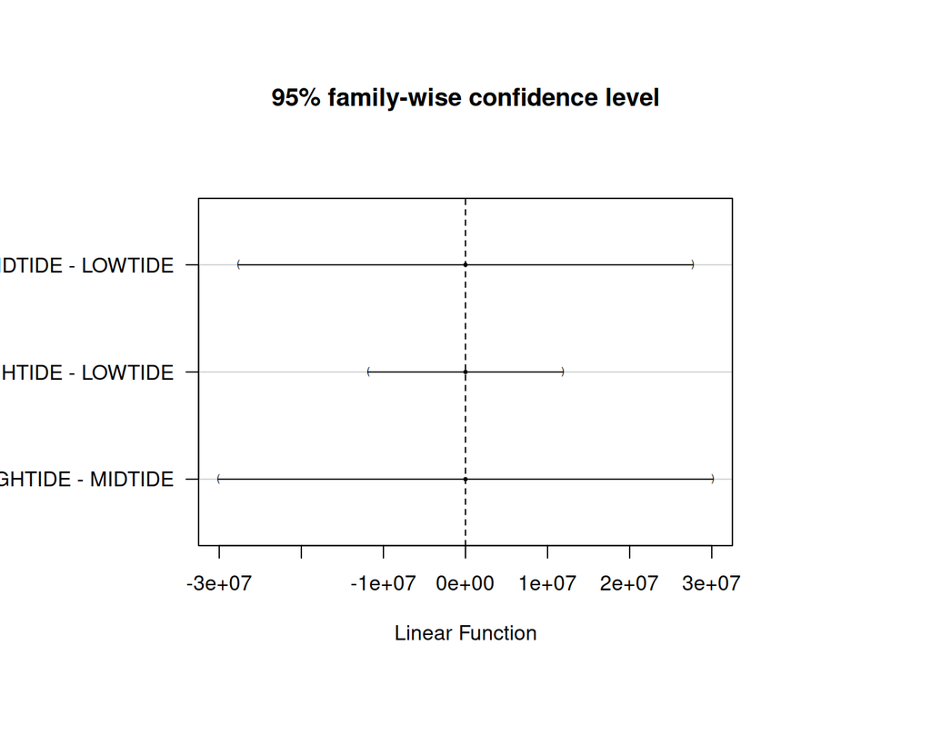

```r
plot(confint(testStrata), cex=0.5)
```

```r
testCountry = glht(model, linfct = mcp("Country" = "Tukey"))
summary(testCountry)
```

```
     Simultaneous Tests for General Linear Hypotheses

Multiple Comparisons of Means: Tukey Contrasts


Fit: glmer(formula = BC ~ Country + Strata + Country * Strata + (1 |
    Site/Quadrat), data = BC_VR995, family = binomial)

Linear Hypotheses:
                            Estimate Std. Error z value Pr(>|z|)
COLOMBIA - ARGENTINA == 0 -8.602e-01  6.774e-01   -1.27    0.367
ECUADOR - ARGENTINA == 0  -1.227e+02  1.223e+07    0.00    1.000
ECUADOR - COLOMBIA == 0   -1.219e+02  1.223e+07    0.00    1.000
(Adjusted p values reported -- single-step method)
```

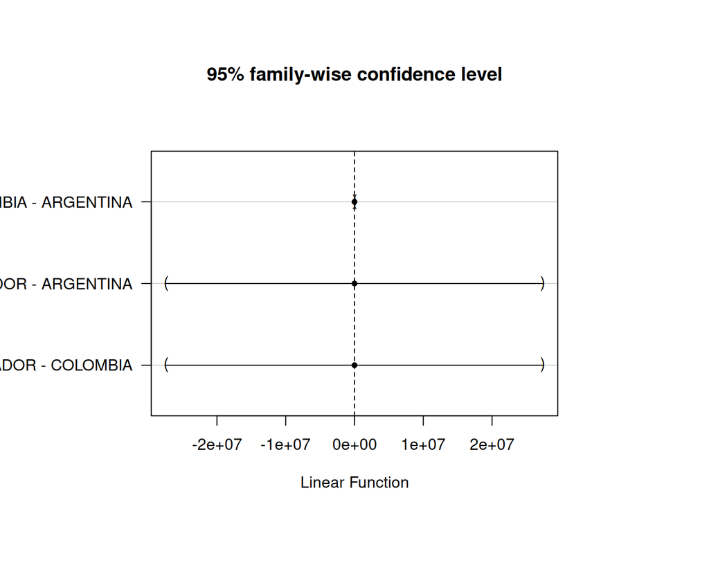

```r
plot(confint(testCountry))
```

```r
BCmean <- round(mean(BC_VR995$BC),3)
BCn <- nrow(BC_VR995)
BCsd <- sd(BC_VR995$BC)
BCmargin <- qt(0.975,df=BCn-1)*BCsd/sqrt(BCn)
BCupper <- round(BCmean + BCmargin, 3)
BClower <- round(BCmean - BCmargin, 3)
```

AS demonstrated, the classifier is insensitive to the variability produced by Country, Site and Strata, being equally efficient no matter the source of the quadrat. **In general, the difference between the classifier and the visual estimate of the community cover of a mean quadrat is 0.13 with a 95% confidence interval of [0.109 - 0.151]**

# Functional groups

According to Gonza’s code the correspondence of `labels` to `funcGroup` is:

| Functional Group | Label |
| --- | --- |
| `ALGAE` | MAF,MAEN,MAA,MAG,MAS,MALCB,MAEC,MAEF,MALA |
| `SUBSTRATE` | SC |
| `INVERTEBRATES` | CRB,MOB,CNTR,WPOT,MOG,CNCA,BRY,CR,MOCH |

### Human vs Robot

```r
DF_FG_HumanRobot <- read_csv(file.path(cleandataDir, "DF_FG_HumanRobot.csv"), col_types = cols())

CM_FG_Human <- DF_FG_HumanRobot %>% filter(source=='human') %>%
  pivot_wider(names_from = 'Label', values_from = 'Cover')

CM_FG_Robot <- DF_FG_HumanRobot %>% filter(source=='robot') %>%
  pivot_wider(names_from = 'Label', values_from = 'Cover')
```

Calculate Bray-Curtis

```r
## calculate BC index
nLabels <- ncol(CM_FG_Human)

BC_FGHR <- data.frame(Country=character(), Site=character(), Strata=character(), BC=numeric())
for (i in 1:nrow(CM_FG_Human)){
  robotIndex <- which(CM_FG_Robot$Name==CM_FG_Human$Name[i])
  if (length(robotIndex) > 0 ){
    CM_one <- bind_rows(CM_FG_Human[i,6:nLabels], CM_FG_Robot[robotIndex,6:nLabels])
    CM_one[is.na(CM_one)] <- 0
    BC_FGHR <- bind_rows(BC_FGHR,
                    data.frame(Country = CM_FG_Human$country[i],
                               Site = CM_FG_Human$site[i],
                               Strata = CM_FG_Human$strata[i],
                               BC = as.numeric(vegdist(CM_one, na.rm = T))))
  }else {
    print(paste0("NOT FOUND in Robot: ", CM_FG_Human$Name[i]))
  }
}
BC_FGHR$Site <- recode_factor(BC_FGHR$Site, PC="Punta Cuevas", PE="Punta Este", PL="Punta Lobos",
                            LM="La Mancora", LV="La Ventana", PV="Playa Verde",
                            CD="Charles Darwin Station", RA="Ratonera", TO="Tortuga Bay",
                            MAMH="MAMH", MAPH="MAPH", MECH="MECH", MEGS="MEGS")
BC_FGHR$Strata <- factor(BC_FGHR$Strata, levels = c("LT", "MT", "HT"), labels = c("LOWTIDE", "MIDTIDE", "HIGHTIDE"))
BC_FGHR$Country <- factor(BC_FGHR$Country, levels = c("AR", "CO", "EC", "US"), labels = c("ARGENTINA", "COLOMBIA", "ECUADOR", "USA"))
```

Summarise the BS distances by groups

```r
BCsummary <- BC_FGHR %>% group_by(Strata) %>%
  summarise(BCmean = mean(BC),
            BCsd = sd(BC),
            BCq25 = quantile(BC, 0.25),
            BCq50 = quantile(BC, 0.50),
            BCq74 = quantile(BC, 0.75),
            BCmin = min(BC),
            BCmax = max(BC))

kable(BCsummary, digits=3, caption = "Functional groups: HUMAN vs. ROBOT") %>% kable_styling("striped")
```

Functional groups: HUMAN vs. ROBOT

| Strata | BCmean | BCsd | BCq25 | BCq50 | BCq74 | BCmin | BCmax |
| --- | --- | --- | --- | --- | --- | --- | --- |
| LOWTIDE | 0.077 | 0.075 | 0.020 | 0.056 | 0.11 | 0 | 0.440 |
| MIDTIDE | 0.062 | 0.087 | 0.014 | 0.040 | 0.08 | 0 | 0.600 |
| HIGHTIDE | 0.042 | 0.065 | 0.000 | 0.020 | 0.05 | 0 | 0.424 |

```r
## global stats
BCsummaryGlobal <- BC_FGHR %>%
  summarise(BCmean = mean(BC),
            BCsd = sd(BC),
            BCq25 = quantile(BC, 0.25),
            BCq50 = quantile(BC, 0.50),
            BCq74 = quantile(BC, 0.75),
            BCmin = min(BC),
            BCmax = max(BC))

kable(BCsummaryGlobal, digits=3, caption = "Functional groups: Human vs Robot global BC stats") %>% kable_styling("striped")
```

Functional groups: Human vs Robot global BC stats

| BCmean | BCsd | BCq25 | BCq50 | BCq74 | BCmin | BCmax |
| --- | --- | --- | --- | --- | --- | --- |
| 0.058 | 0.078 | 0.01 | 0.03 | 0.078 | 0 | 0.6 |

PLOTs

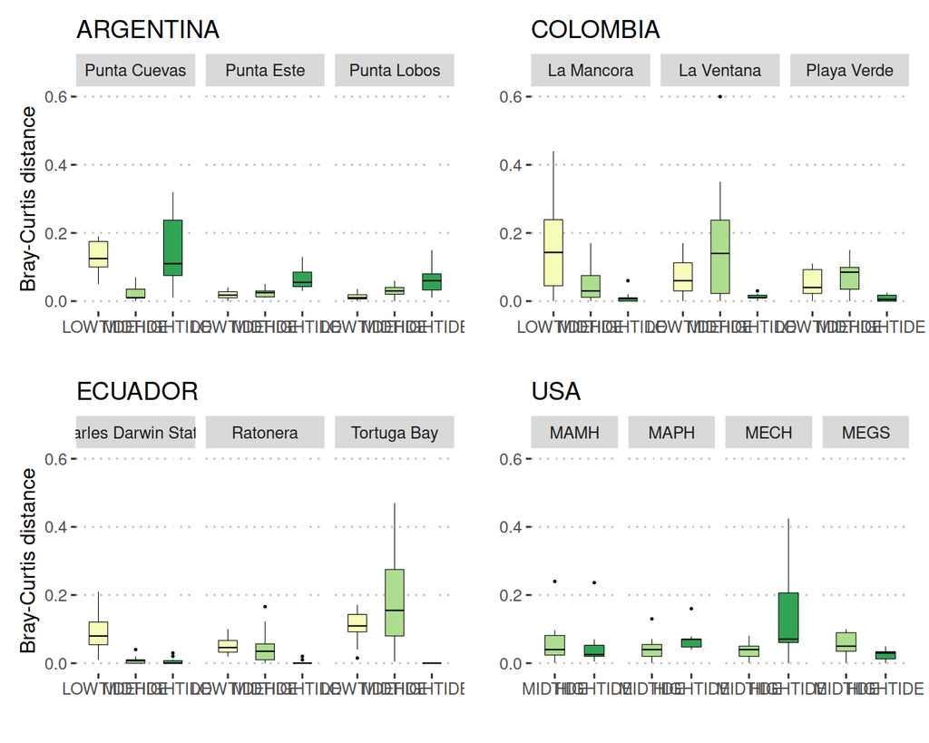

```r
pp_ARG <- ggplot(BC_FGHR %>% filter(Country=="ARGENTINA"), aes(Strata, BC))
pp_ARG <- pp_ARG + geom_boxplot(width=0.5, aes(fill=Strata), colour="black", outlier.size = 0.3, lwd=0.2) +
  ylim(0,0.6) +
  scale_color_manual(values = strataColor, aesthetics = 'fill') +
  labs(title="ARGENTINA", x="", y="Bray-Curtis distance") +
  facet_grid(~Site) +
  theme_pubclean() +
  theme(legend.position = 'none')

pp_COL <- ggplot(BC_FGHR %>% filter(Country=="COLOMBIA"), aes(Strata, BC))
pp_COL <- pp_COL + geom_boxplot(width=0.5, aes(fill=Strata), colour="black", outlier.size = 0.3, lwd=0.2) +
  ylim(0,0.6) +
  scale_color_manual(values = strataColor, aesthetics = 'fill') +
  labs(title="COLOMBIA", x="", y=" ") +
  facet_grid(~Site) +
  theme_pubclean() +
  theme(legend.position = 'none')

pp_ECU <- ggplot(BC_FGHR %>% filter(Country=="ECUADOR"), aes(Strata, BC))
pp_ECU <- pp_ECU + geom_boxplot(width=0.5, aes(fill=Strata), colour="black", outlier.size = 0.3, lwd=0.2) +
  ylim(0,0.6) +
  scale_color_manual(values = strataColor, aesthetics = 'fill') +
  labs(title="ECUADOR", x="", y="Bray-Curtis distance") +
  facet_grid(~Site) +
  theme_pubclean() +
  theme(legend.position = 'none')

pp_USA <- ggplot(BC_FGHR %>% filter(Country=="USA"), aes(Strata, BC))
pp_USA <- pp_USA + geom_boxplot(width=0.5, aes(fill=Strata), colour="black", outlier.size = 0.3, lwd=0.2) +
  ylim(0,0.6) +
  scale_color_manual(values = strataColor, aesthetics = 'fill') +
  labs(title="USA", x="", y=" ") +
  facet_grid(~Site) +
  theme_pubclean() +
  theme(legend.position = 'none')

(pp_ARG + pp_COL) / (pp_ECU + pp_USA)
```

Let’s try another version

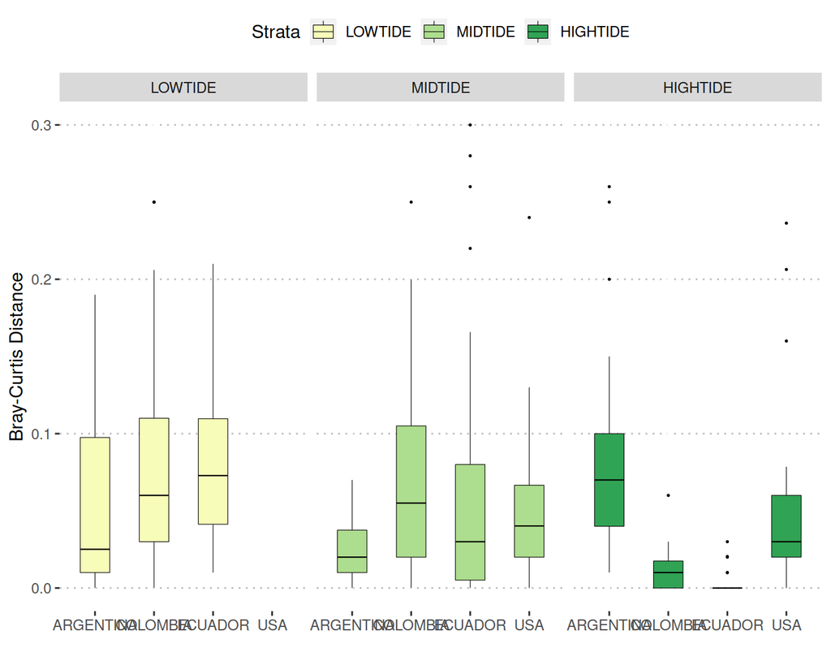

```r
pp <- ggplot(BC_FGHR, aes(Country, BC, fill=Strata))
pp + geom_boxplot(width=0.5, aes(fill=Strata), colour="black", position=position_dodge2(preserve="single") , outlier.size = 0.3, lwd=0.2) +
  scale_color_manual(values = strataColor, aesthetics = 'fill') +
  ylim(0, 0.3) +
  labs(x="", y="Bray-Curtis Distance") +
  facet_grid(~Strata) +
  theme_pubclean()
```

GMM model

```r
BC_FGHR <- BC_FGHR %>% group_by(Country, Site, Strata) %>% mutate(Quadrat = seq_len(n()))


model = glmer(BC ~ Country + Strata + Country*Strata + (1|Site/Quadrat), data=BC_FGHR, family=binomial)
summary(model)
```

```
Generalized linear mixed model fit by maximum likelihood (Laplace Approximation) ['glmerMod']
 Family: binomial  ( logit )
Formula: BC ~ Country + Strata + Country * Strata + (1 | Site/Quadrat)
   Data: BC_FGHR

     AIC      BIC   logLik deviance df.resid
    34.8     85.4     -4.4      8.8      349

Scaled residuals:
     Min       1Q   Median       3Q      Max
       0   264625  2013266  4625137 31541166

Random effects:
 Groups       Name        Variance Std.Dev.
 Quadrat:Site (Intercept) 0        0
 Site         (Intercept) 0        0
Number of obs: 362, groups:  Quadrat:Site, 144; Site, 13

Fixed effects:
                                 Estimate Std. Error z value Pr(>|z|)
(Intercept)                    -2.416e+02  1.112e+07       0        1
CountryCOLOMBIA                 4.713e+01  1.654e+07       0        1
CountryECUADOR                  3.072e+01  1.655e+07       0        1
CountryUSA                      3.487e+01  1.575e+07       0        1
StrataMIDTIDE                   2.645e+01  1.656e+07       0        1
StrataHIGHTIDE                  3.209e+01  1.655e+07       0        1
CountryCOLOMBIA:StrataMIDTIDE   1.646e+02  2.059e+07       0        1
CountryECUADOR:StrataMIDTIDE   -6.062e+01  2.397e+07       0        1
CountryUSA:StrataMIDTIDE        1.349e+02  2.231e+07       0        1
CountryCOLOMBIA:StrataHIGHTIDE -6.545e+01  2.395e+07       0        1
CountryECUADOR:StrataHIGHTIDE   1.448e+02  2.105e+07       0        1

Correlation of Fixed Effects:
             (Intr) CnCOLOMBIA CnECUADOR CntUSA SMIDTI SHIGHT CCOLOMBIA:SM CECUADOR:SM CUSA:S
CntCOLOMBIA  -0.672
CntrECUADOR  -0.672  0.452
CountryUSA    0.000  0.000      0.000
StrtMIDTIDE  -0.668  0.449      0.449     0.000
StrHIGHTIDE  -0.672  0.452      0.452    -0.576  0.449
CCOLOMBIA:SM  0.537 -0.801     -0.361     0.000 -0.804 -0.361
CECUADOR:SM   0.461 -0.310     -0.689     0.000 -0.691 -0.310  0.555
CUSA:SMIDTI  -0.003  0.002      0.002    -0.706 -0.409  0.409  0.329        0.283
CCOLOMBIA:SH  0.464 -0.690     -0.312     0.398 -0.310 -0.691  0.553        0.214      -0.282
CECUADOR:SH   0.528 -0.355     -0.786     0.453 -0.353 -0.786  0.284        0.541      -0.321
             CCOLOMBIA:SH
CntCOLOMBIA
CntrECUADOR
CountryUSA
StrtMIDTIDE
StrHIGHTIDE
CCOLOMBIA:SM
CECUADOR:SM
CUSA:SMIDTI
CCOLOMBIA:SH
CECUADOR:SH   0.543
fit warnings:
fixed-effect model matrix is rank deficient so dropping 1 column / coefficient
convergence code: 0
boundary (singular) fit: see ?isSingular
```

```r
testStrata = glht(model, linfct = mcp("Strata" = "Tukey"))
summary(testStrata)
```

```
     Simultaneous Tests for General Linear Hypotheses

Multiple Comparisons of Means: Tukey Contrasts


Fit: glmer(formula = BC ~ Country + Strata + Country * Strata + (1 |
    Site/Quadrat), data = BC_FGHR, family = binomial)

Linear Hypotheses:
                         Estimate Std. Error z value Pr(>|z|)
MIDTIDE - LOWTIDE == 0  2.645e+01  1.656e+07       0        1
HIGHTIDE - LOWTIDE == 0 3.209e+01  1.655e+07       0        1
HIGHTIDE - MIDTIDE == 0 5.642e+00  1.738e+07       0        1
(Adjusted p values reported -- single-step method)
```

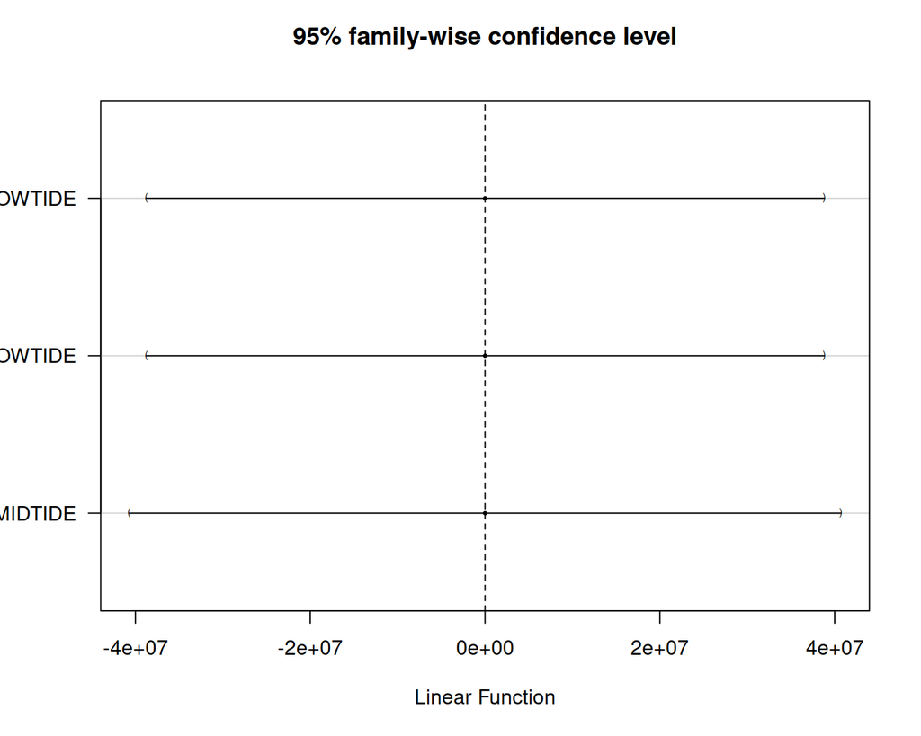

```r
plot(confint(testStrata), cex=0.5)
```

```r
testCountry = glht(model, linfct = mcp("Country" = "Tukey"))
summary(testCountry)
```

```
     Simultaneous Tests for General Linear Hypotheses

Multiple Comparisons of Means: Tukey Contrasts


Fit: glmer(formula = BC ~ Country + Strata + Country * Strata + (1 |
    Site/Quadrat), data = BC_FGHR, family = binomial)

Linear Hypotheses:
                            Estimate Std. Error z value Pr(>|z|)
COLOMBIA - ARGENTINA == 0  4.713e+01  1.654e+07       0        1
ECUADOR - ARGENTINA == 0   3.073e+01  1.655e+07       0        1
USA - ARGENTINA == 0       3.487e+01  1.575e+07       0        1
ECUADOR - COLOMBIA == 0   -1.640e+01  1.733e+07       0        1
USA - COLOMBIA == 0       -1.226e+01  2.284e+07       0        1
USA - ECUADOR == 0         4.145e+00  2.284e+07       0        1
(Adjusted p values reported -- single-step method)
```

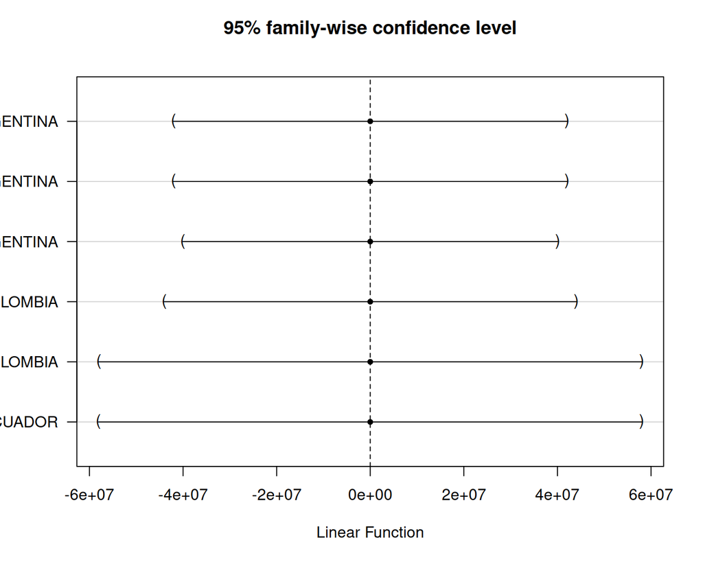

```r
plot(confint(testCountry))
```

```r
BCmean <- round(mean(BC_FGHR$BC),3)
BCn <- nrow(BC_FGHR)
BCsd <- sd(BC_FGHR$BC)
BCmargin <- qt(0.975,df=BCn-1)*BCsd/sqrt(BCn)
BCupper <- round(BCmean + BCmargin, 3)
BClower <- round(BCmean - BCmargin, 3)
```

### Visual vs Robot

```r
DF_FG_VisualRobot <- read_csv(file.path(cleandataDir, "DF_FG_VisualRobot.csv"), col_types = cols())

CM_FG_Visual <- DF_FG_VisualRobot %>% filter(source=='visual') %>%
  pivot_wider(names_from = 'Label', values_from = 'Cover')

CM_FG_Robot <- DF_FG_VisualRobot %>% filter(source=='robot') %>%
  pivot_wider(names_from = 'Label', values_from = 'Cover')
```

Calculate Bray-Curtis

```r
## calculate BC index
nLabels <- ncol(CM_FG_Visual)

BC_FGVR <- data.frame(Country=character(), Site=character(), Strata=character(), BC=numeric())
for (i in 1:nrow(CM_FG_Visual)){
  robotIndex <- which(CM_FG_Robot$Name==CM_FG_Visual$Name[i])
  if (length(robotIndex) > 0 ){
    CM_one <- bind_rows(CM_FG_Visual[i,6:nLabels], CM_FG_Robot[robotIndex,6:nLabels])
    CM_one[is.na(CM_one)] <- 0
    BC_FGVR <- bind_rows(BC_FGVR,
                    data.frame(Country = CM_FG_Visual$country[i],
                               Site = CM_FG_Visual$site[i],
                               Strata = CM_FG_Visual$strata[i],
                               BC = as.numeric(vegdist(CM_one, na.rm = T))))
  }else {
    print(paste0("NOT FOUND in Robot: ", CM_FG_Visual$Name[i]))
  }
}
BC_FGVR$Site <- recode_factor(BC_FGVR$Site, PC="Punta Cuevas", PE="Punta Este", PL="Punta Lobos",
                            LM="La Mancora", LV="La Ventana", PV="Playa Verde",
                            CD="Charles Darwin Station", RA="Ratonera", TO="Tortuga Bay",
                            MAMH="MAMH", MAPH="MAPH", MECH="MECH", MEGS="MEGS")
BC_FGVR$Strata <- factor(BC_FGVR$Strata, levels = c("LT", "MT", "HT"), labels = c("LOWTIDE", "MIDTIDE", "HIGHTIDE"))
BC_FGVR$Country <- factor(BC_FGVR$Country, levels = c("AR", "CO", "EC"), labels = c("ARGENTINA", "COLOMBIA", "ECUADOR"))
```

Summarise the BS distances by groups

```r
BCsummary <- BC_FGVR %>% group_by(Strata) %>%
  summarise(BCmean = mean(BC),
            BCsd = sd(BC),
            BCq25 = quantile(BC, 0.25),
            BCq50 = quantile(BC, 0.50),
            BCq74 = quantile(BC, 0.75),
            BCmin = min(BC),
            BCmax = max(BC))

kable(BCsummary, digits=3, caption = "Functional groups: VISUAL vs. ROBOT") %>% kable_styling("striped")
```

Functional groups: VISUAL vs. ROBOT

| Strata | BCmean | BCsd | BCq25 | BCq50 | BCq74 | BCmin | BCmax |
| --- | --- | --- | --- | --- | --- | --- | --- |
| LOWTIDE | 0.120 | 0.120 | 0.026 | 0.080 | 0.174 | 0 | 0.54 |
| MIDTIDE | 0.103 | 0.125 | 0.020 | 0.050 | 0.162 | 0 | 0.62 |
| HIGHTIDE | 0.060 | 0.102 | 0.000 | 0.013 | 0.070 | 0 | 0.47 |

```r
## global stats
BCsummaryGlobal <- BC_FGVR %>%
  summarise(BCmean = mean(BC),
            BCsd = sd(BC),
            BCq25 = quantile(BC, 0.25),
            BCq50 = quantile(BC, 0.50),
            BCq74 = quantile(BC, 0.75),
            BCmin = min(BC),
            BCmax = max(BC))

kable(BCsummaryGlobal, digits=3, caption = "Functional groups: VISUAL vs ROBOT global BC stats") %>% kable_styling("striped")
```

Functional groups: VISUAL vs ROBOT global BC stats

| BCmean | BCsd | BCq25 | BCq50 | BCq74 | BCmin | BCmax |
| --- | --- | --- | --- | --- | --- | --- |
| 0.094 | 0.119 | 0.01 | 0.04 | 0.138 | 0 | 0.62 |

PLOTs

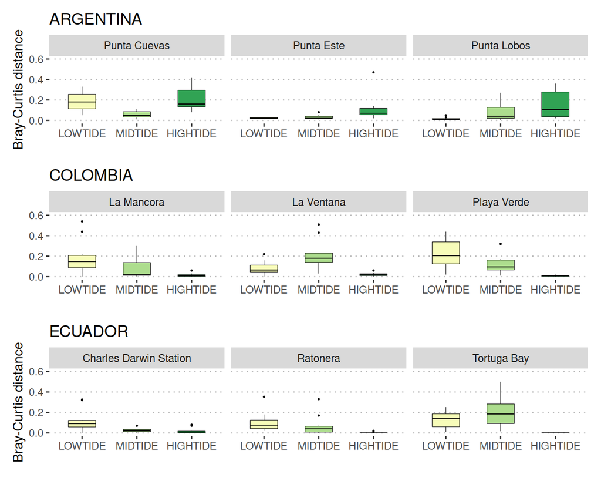

```r
pp_ARG <- ggplot(BC_FGVR %>% filter(Country=="ARGENTINA"), aes(Strata, BC))
pp_ARG <- pp_ARG + geom_boxplot(width=0.5, aes(fill=Strata), colour="black", outlier.size = 0.3, lwd=0.2) +
  ylim(0,0.6) +
  scale_color_manual(values = strataColor, aesthetics = 'fill') +
  labs(title="ARGENTINA", x="", y="Bray-Curtis distance") +
  facet_grid(~Site) +
  theme_pubclean() +
  theme(legend.position = 'none')

pp_COL <- ggplot(BC_FGVR %>% filter(Country=="COLOMBIA"), aes(Strata, BC))
pp_COL <- pp_COL + geom_boxplot(width=0.5, aes(fill=Strata), colour="black", outlier.size = 0.3, lwd=0.2) +
  ylim(0,0.6) +
  scale_color_manual(values = strataColor, aesthetics = 'fill') +
  labs(title="COLOMBIA", x="", y=" ") +
  facet_grid(~Site) +
  theme_pubclean() +
  theme(legend.position = 'none')

pp_ECU <- ggplot(BC_FGVR %>% filter(Country=="ECUADOR"), aes(Strata, BC))
pp_ECU <- pp_ECU + geom_boxplot(width=0.5, aes(fill=Strata), colour="black", outlier.size = 0.3, lwd=0.2) +
  ylim(0,0.6) +
  scale_color_manual(values = strataColor, aesthetics = 'fill') +
  labs(title="ECUADOR", x="", y="Bray-Curtis distance") +
  facet_grid(~Site) +
  theme_pubclean() +
  theme(legend.position = 'none')

pp_ARG / pp_COL / pp_ECU
```

Let’s try another version

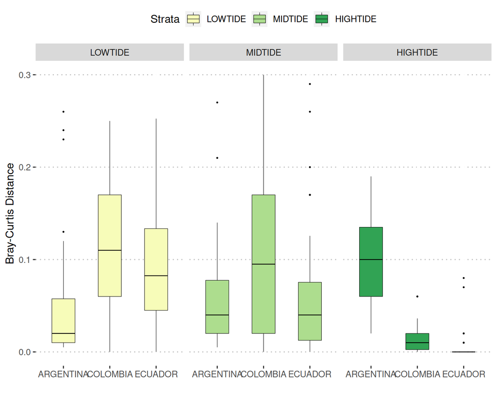

```r
pp <- ggplot(BC_FGVR, aes(Country, BC, fill=Strata))
pp + geom_boxplot(width=0.5, aes(fill=Strata), colour="black", position=position_dodge2(preserve="single") , outlier.size = 0.3, lwd=0.2) +
  scale_color_manual(values = strataColor, aesthetics = 'fill') +
  ylim(0, 0.3) +
  labs(x="", y="Bray-Curtis Distance") +
  facet_grid(~Strata) +
  theme_pubclean()
```

GML model

```r
## prepare data
BC_FGVR <- BC_FGVR %>% group_by(Country, Site, Strata) %>% mutate(Quadrat = seq_len(n()))
```

Full model

```r
model = glm(BC ~ Country*Strata, data=BC_FGVR, family=binomial)
summary(model)
```

```
Call:
glm(formula = BC ~ Country * Strata, family = binomial, data = BC_FGVR)

Deviance Residuals:
     Min        1Q    Median        3Q       Max
-0.60357  -0.24353  -0.11853   0.08143   1.06280

Coefficients:
                               Estimate Std. Error z value Pr(>|z|)
(Intercept)                     -2.5217     0.6959  -3.623 0.000291 ***
CountryCOLOMBIA                  0.9113     0.8512   1.071 0.284367
CountryECUADOR                   0.5075     0.8974   0.566 0.571677
StrataMIDTIDE                   -0.2689     1.0469  -0.257 0.797324
StrataHIGHTIDE                   0.8536     0.8568   0.996 0.319131
CountryCOLOMBIA:StrataMIDTIDE    0.1642     1.2626   0.130 0.896506
CountryECUADOR:StrataMIDTIDE     0.0734     1.3383   0.055 0.956263
CountryCOLOMBIA:StrataHIGHTIDE  -3.4474     1.8094  -1.905 0.056744 .
CountryECUADOR:StrataHIGHTIDE   -3.7942     2.4185  -1.569 0.116695
---
Signif. codes:  0 '***' 0.001 '**' 0.01 '*' 0.05 '.' 0.1 ' ' 1

(Dispersion parameter for binomial family taken to be 1)

    Null deviance: 38.585  on 269  degrees of freedom
Residual deviance: 26.205  on 261  degrees of freedom
AIC: 82.587

Number of Fisher Scoring iterations: 7
```

```r
testCountry = glht(model, linfct = mcp("Country" = "Tukey"))
summary(testCountry)
```

```
     Simultaneous Tests for General Linear Hypotheses

Multiple Comparisons of Means: Tukey Contrasts


Fit: glm(formula = BC ~ Country * Strata, family = binomial, data = BC_FGVR)

Linear Hypotheses:
                          Estimate Std. Error z value Pr(>|z|)
COLOMBIA - ARGENTINA == 0   0.9112     0.8512   1.071    0.531
ECUADOR - ARGENTINA == 0    0.5075     0.8974   0.566    0.838
ECUADOR - COLOMBIA == 0    -0.4037     0.7491  -0.539    0.851
(Adjusted p values reported -- single-step method)
```

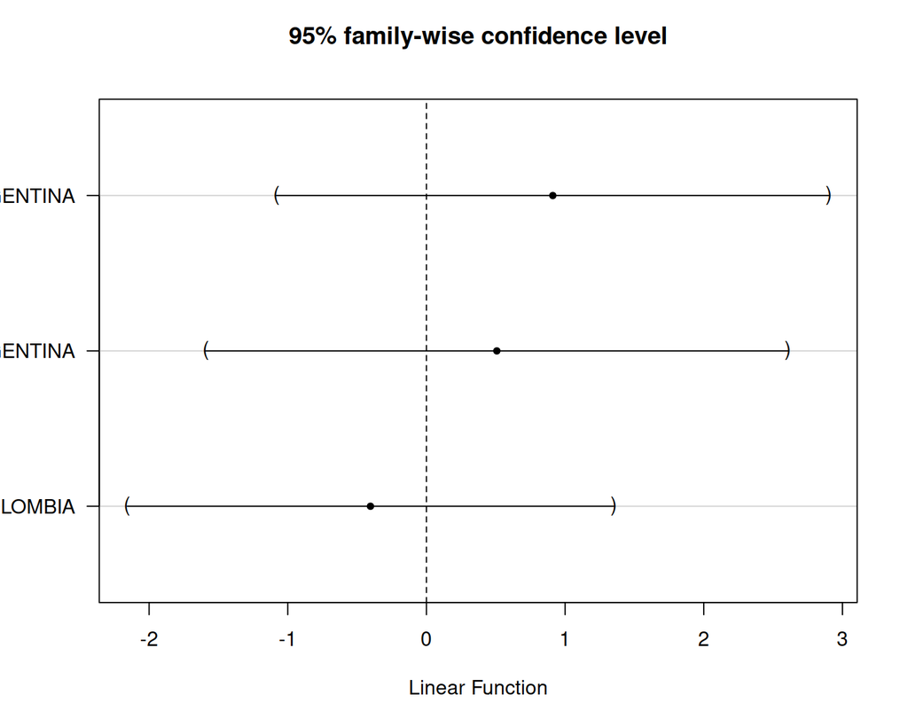

```r
plot(confint(testCountry))
```

```r
testCountry = glht(model, linfct = mcp("Strata" = "Tukey"))
summary(testCountry)
```

```
     Simultaneous Tests for General Linear Hypotheses

Multiple Comparisons of Means: Tukey Contrasts


Fit: glm(formula = BC ~ Country * Strata, family = binomial, data = BC_FGVR)

Linear Hypotheses:
                        Estimate Std. Error z value Pr(>|z|)
MIDTIDE - LOWTIDE == 0   -0.2689     1.0469  -0.257    0.964
HIGHTIDE - LOWTIDE == 0   0.8536     0.8568   0.996    0.577
HIGHTIDE - MIDTIDE == 0   1.1224     0.9281   1.209    0.445
(Adjusted p values reported -- single-step method)
```

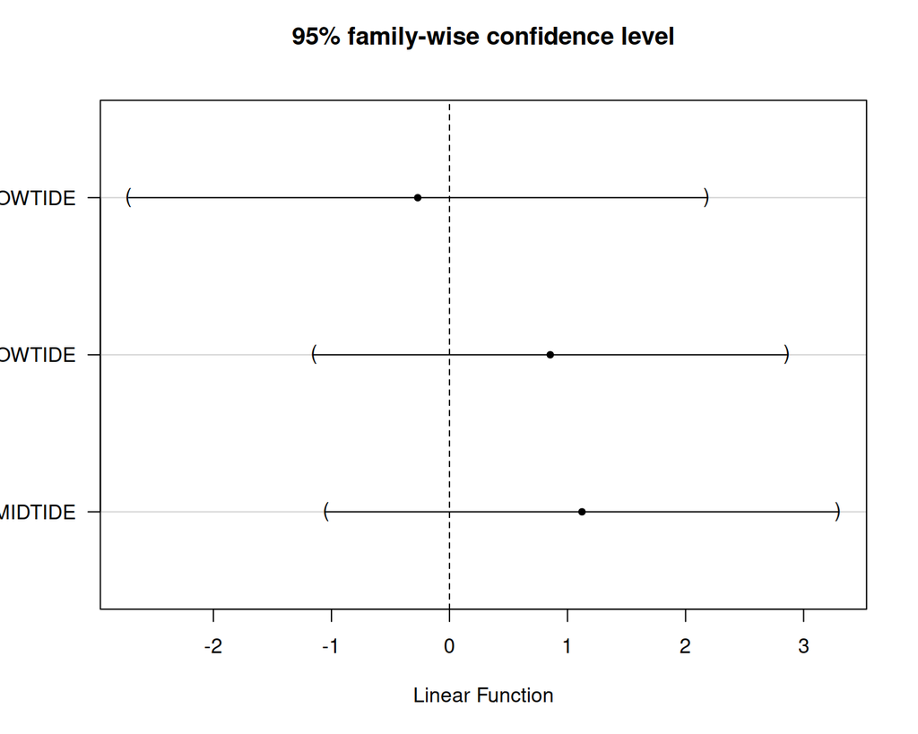

```r
plot(confint(testCountry))
```

By STRATUM

HIGHTIDE

```r
model = glm(BC ~ Country, data=BC_FGVR, subset = Strata=="HIGHTIDE", family=binomial)
summary(model)
```

```
Call:
glm(formula = BC ~ Country, family = binomial, data = BC_FGVR,
    subset = Strata == "HIGHTIDE")

Deviance Residuals:
    Min       1Q   Median       3Q      Max
-0.4650  -0.1344  -0.1185   0.0397   0.7287

Coefficients:
                Estimate Std. Error z value Pr(>|z|)
(Intercept)      -1.6682     0.4997  -3.338 0.000843 ***
CountryCOLOMBIA  -2.5361     1.5967  -1.588 0.112198
CountryECUADOR   -3.2866     2.2459  -1.463 0.143357
---
Signif. codes:  0 '***' 0.001 '**' 0.01 '*' 0.05 '.' 0.1 ' ' 1

(Dispersion parameter for binomial family taken to be 1)

    Null deviance: 12.3059  on 89  degrees of freedom
Residual deviance:  4.7393  on 87  degrees of freedom
AIC: 17.677

Number of Fisher Scoring iterations: 7
```

```r
testCountry = glht(model, linfct = mcp("Country" = "Tukey"))
summary(testCountry)
```

```
     Simultaneous Tests for General Linear Hypotheses

Multiple Comparisons of Means: Tukey Contrasts


Fit: glm(formula = BC ~ Country, family = binomial, data = BC_FGVR,
    subset = Strata == "HIGHTIDE")

Linear Hypotheses:
                          Estimate Std. Error z value Pr(>|z|)
COLOMBIA - ARGENTINA == 0  -2.5361     1.5967  -1.588    0.240
ECUADOR - ARGENTINA == 0   -3.2866     2.2459  -1.463    0.297
ECUADOR - COLOMBIA == 0    -0.7505     2.6634  -0.282    0.955
(Adjusted p values reported -- single-step method)
```